# Lição 2 e 3

2026-03-24

**EXERCÍCIO 2**

Carregando pacotes

```r
library(ggplot2)
library(tidyverse)
library(dplyr)
library(knitr)
library(kableExtra)
```

Importação de dados

**Ex 1**

```r
municipios <- read.csv("C:/Users/Gustavo/Downloads/municipios_virgula.csv")
View(municipios)
str(municipios)
```

```
## 'data.frame':    15 obs. of  5 variables:
##  $ nome_municipio: chr  "São Paulo" "Rio de Janeiro" "Belo Horizonte" "Salvador" ...
##  $ uf            : chr  "SP" "RJ" "MG" "BA" ...
##  $ populacao     : int  11451999 6211423 2315560 2418005 1773733 2428678 2063547 1555039 1332570 1303389 ...
##  $ idh           : num  0.805 0.799 0.81 0.759 0.823 0.754 0.737 0.772 0.805 0.746 ...
##  $ pib_per_capita: num  54258 49528 33049 20233 42935 ...
```

R: temos 15 municípios divididos em 5 colunas: nome_municipio, uf, populacao, idh e pib_per_capita

**Ex 2**

```r
# <- read.csv("C:/Users/Gustavo/Downloads/municipios_pontovirgula.csv")

municipos2 <- read.csv2("C:/Users/Gustavo/Downloads/municipios_pontovirgula.csv",
                        fileEncoding = "latin1")
```

R: primeiro aparece erro de leitura do código porque não é a formatação padrão de leitura dos arquivos csv. Comumente é observado em csvs a repartição de itens por vírgulas, não ponto e vírgula e as variaveis não inteiras tem os algarismos decimais partidos por ponto final, não vírgula como na língua brasileira.

**Ex 3**

```r
eleicoes22 <- read.csv("C:/Users/Gustavo/Downloads/eleicoes_2022.csv")
filter(eleicoes22, municipio == "Pau D'Arco")
```

| municipio | uf | candidato | partido | votos | percentual |
| --- | --- | --- | --- | --- | --- |
| Pau D'Arco | PA | Lula | PT | 2345 | 55.37 |
| Pau D'Arco | PA | Bolsonaro | PL | 1890 | 44.63 |

R: A importação deu certo

**Ex 4**

```r
IDH_municipios <- read.csv2("C:/Users/Gustavo/Downloads/idh_municipios.csv",
                            fileEncoding = "latin1")
str(IDH_municipios)
```

```
## 'data.frame':    25 obs. of  9 variables:
##  $ cod_ibge       : int  3550308 3304557 3106200 2927408 4106902 2304400 1302603 2611606 4314902 1501402 ...
##  $ municipio      : chr  "São Paulo" "Rio de Janeiro" "Belo Horizonte" "Salvador" ...
##  $ uf             : chr  "SP" "RJ" "MG" "BA" ...
##  $ regiao         : chr  "Sudeste" "Sudeste" "Sudeste" "Nordeste" ...
##  $ idh_2010       : num  0.805 0.799 0.81 0.759 0.823 0.754 0.737 0.772 0.805 0.746 ...
##  $ idh_educacao   : num  0.725 0.719 0.737 0.661 0.768 0.672 0.658 0.698 0.727 0.673 ...
##  $ idh_longevidade: num  0.855 0.845 0.856 0.835 0.855 0.824 0.812 0.825 0.857 0.818 ...
##  $ idh_renda      : num  0.843 0.84 0.841 0.79 0.85 0.773 0.75 0.798 0.835 0.756 ...
##  $ populacao_2010 : int  11253503 6320446 2375151 2675656 1751907 2452185 1802014 1537704 1409351 1393399 ...
```

R: Sim, são numéricas

**Ex 6**

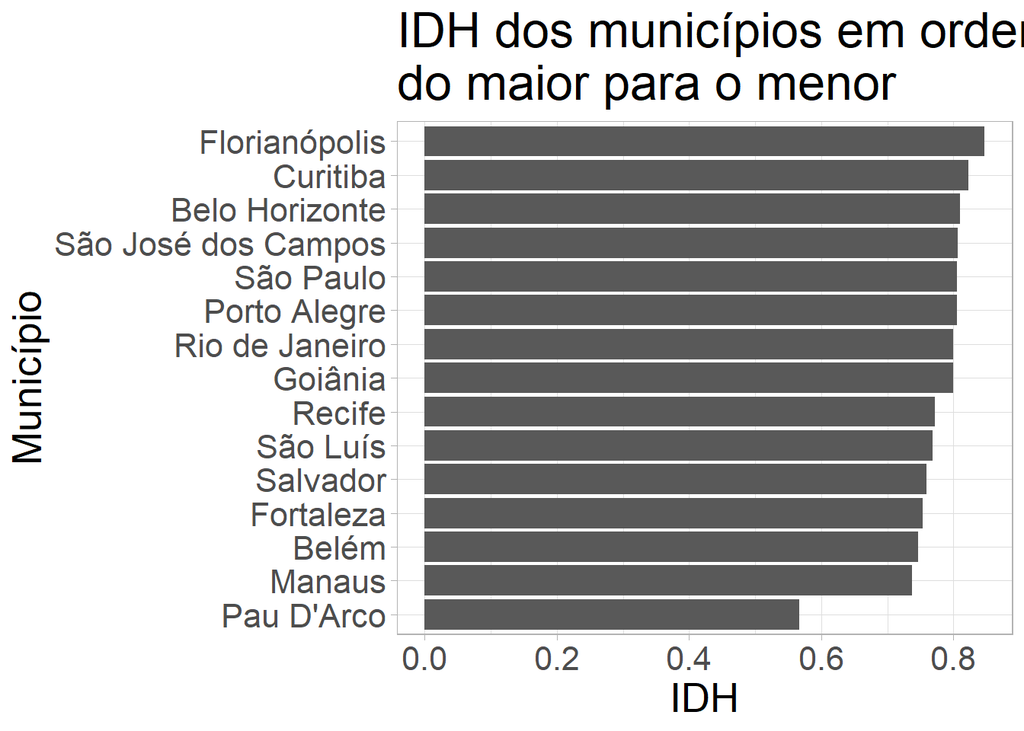

```r
municipios %>%
  ggplot(aes(x = idh, y = reorder(nome_municipio, idh))) + geom_col() +
  xlab("IDH") + ylab("Município") +
  theme_light() + theme(text=element_text(size = 20)) +
  ggtitle("IDH dos municípios em ordem\ndo maior para o menor")
```

R: Florianópolis apresenta maior IDH e Pau D’Arco menor IDH

**Ex 7**

```r
df <- municipios %>%
  summarise('populacao total' = sum(populacao),
            'populacao media' = mean(populacao))
kable(df)
```

| populacao total | populacao media |
| --- | --- |
| 36601670 | 2440111 |

R: Temos soma igual a 36601670 e média 2440111

**Ex 8**

```r
df <- eleicoes22 %>%
  group_by(candidato) %>%
  summarise(soma_candidatos = sum(votos)) %>%
  arrange(desc(soma_candidatos))
kable(df)
```

| candidato | soma_candidatos |
| --- | --- |
| Lula | 8249244 |
| Bolsonaro | 6861801 |
| Simone Tebet | 758133 |
| Ciro Gomes | 355023 |

R: Essa é a votação final, indicando “Lula” como vencedor

**Ex 9**

```r
df <- IDH_municipios %>%
  group_by(regiao) %>%
  summarise(soma_idh = mean(idh_2010)) %>%
  arrange(desc(soma_idh))
kable(df)
```

| regiao | soma_idh |
| --- | --- |
| Sul | 0.8250000 |
| Centro-Oeste | 0.7980000 |
| Sudeste | 0.7955000 |
| Nordeste | 0.7581429 |
| Norte | 0.7518000 |

R: Sul tem maior IDH médio e Norte menor IDH médio

**Ex 10**

```r
df <- eleicoes22 %>%
  group_by(municipio) %>%
  slice_max(order_by = votos) %>%
  ungroup() %>%
  mutate(vencedor = candidato)
kable(df)
```

| municipio | uf | candidato | partido | votos | percentual | vencedor |
| --- | --- | --- | --- | --- | --- | --- |
| Belo Horizonte | MG | Lula | PT | 876543 | 52.55 | Lula |
| Florianópolis | SC | Bolsonaro | PL | 178901 | 57.08 | Bolsonaro |
| Pau D’Arco | PA | Lula | PT | 2345 | 55.37 | Lula |
| Rio de Janeiro | RJ | Lula | PT | 2345678 | 49.63 | Lula |
| Salvador | BA | Lula | PT | 1123456 | 63.97 | Lula |
| São José dos Campos | SP | Bolsonaro | PL | 245678 | 55.28 | Bolsonaro |
| São Paulo | SP | Lula | PT | 3567890 | 48.82 | Lula |

R: Exceto por Florianópolis e São Jóse dos Campos, que indicam “Bolsonaro” como vencedor, os demais municípios apresentam vitória de “Lula”

**Ex 13**

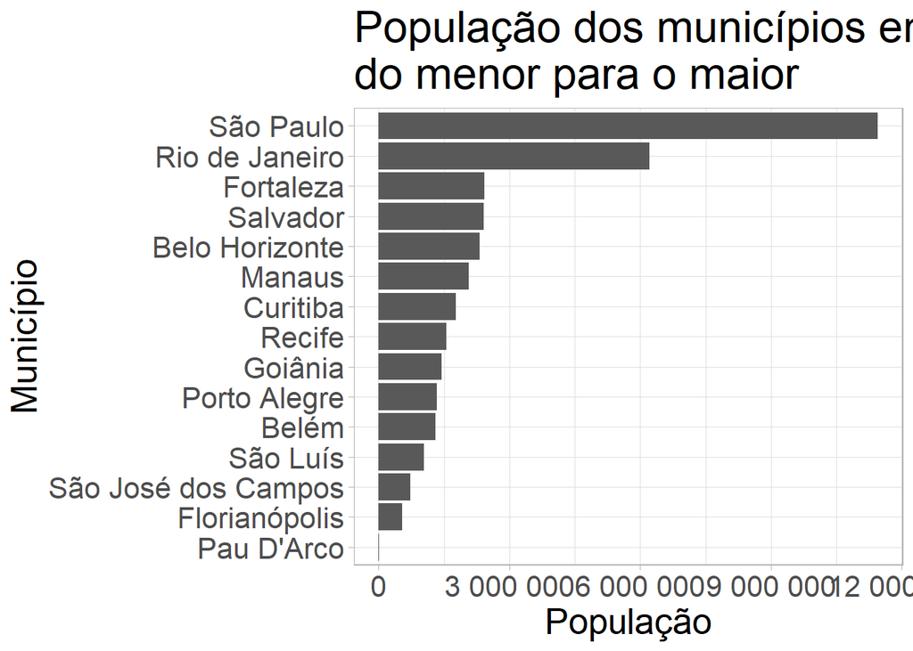

```r
municipios %>%
  ggplot(aes(x = reorder(nome_municipio, populacao), y = populacao)) + geom_col() +
  xlab("Município") + ylab("População") + coord_flip() +
  theme_light() + theme(text = element_text(size = 20)) +
  ggtitle("População dos municípios em ordem\ndo menor para o maior") +
  scale_y_continuous(labels = scales::label_number(accuracy = 1))
```

R: São Paulo apresenta população muito numericamente superior que o Rio de Janeiro, que também é 2 vezes maior numericamente que Fortaleza, terceiro na ordem, mantendo uma decrescente gradual menos exorbitante que os primeiros dois mencionados

**Ex 14**

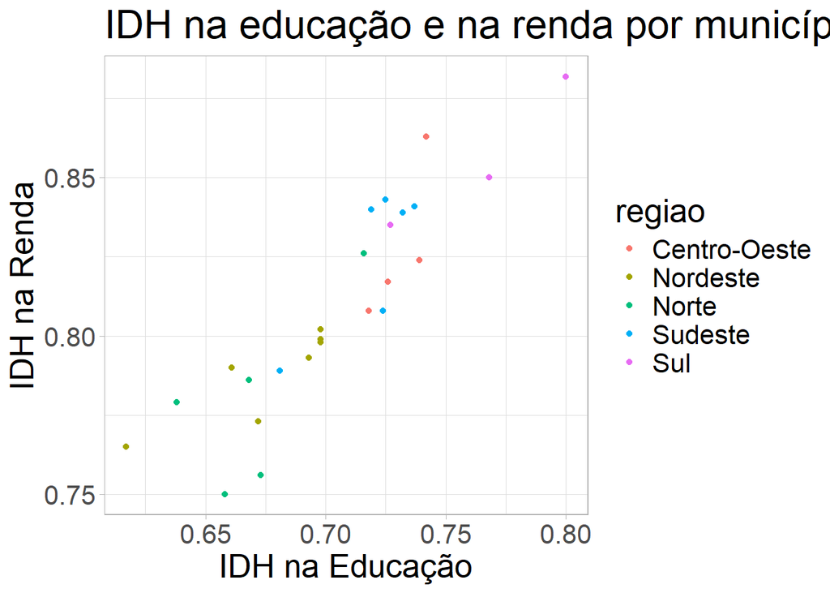

```r
IDH_municipios %>%
  ggplot(aes(x = idh_educacao, y = idh_renda, color = regiao)) + geom_point() +
  xlab("IDH na Educação") + ylab("IDH na Renda") +
  theme_light() + theme(text=element_text(size = 20)) +
  ggtitle("IDH na educação e na renda por municípios")
```

R: Sul, Suldeste e Centro-Oeste apresentam IDH de renda e de educação maiores do que as regiões Norte e Nordeste

**EXERCÍCIO 3**

**Ex 1:5**

Link para github referente aos exercícios sobre github: https://github.com/guhstar/exercicio-stat-basica

**Ex 5 e 6 (? Markdown)**

**Texto Negrito** e *Texto itálico*

Lista numerada:

1. Item 1
2. Item 2
3. Item 3

```r
valores <- c(10, 20, 30, 40, 50)
media <- mean(valores)
media
```

```
## [1] 30
```

R: Média calculada com sucesso, lista feita e textos realizados

**Ex 7**

| ano | codigo_regiao | nome_regiao | codigo_uf | sigla_uf | nome_uf | cod_municipio | nome_munic | nome_metro | codigo_meso | nome_meso | codigo_micro | nome_micro | codigo_reg_geo_imediata | nome_reg_geo_imediata | mun_reg_geo_imediata | codigo_reg_geo_intermediaria | nome_reg_geo_intermediaria | mun_reg_geo_intermediaria | codigo_concentracao_urbana | nome_concentracao_urbana | tipo_concentracao_urbana | codigo_arranjo_populacional | nome_arranjo_populacional | hierarquia_urbana | hierarquia_urbana_principais | codigo_regiao_rural | nome_regiao_rural | regiao_rural_classificacao | amazonia_legal | … |
| --- | --- | --- | --- | --- | --- | --- | --- | --- | --- | --- | --- | --- | --- | --- | --- | --- | --- | --- | --- | --- | --- | --- | --- | --- | --- | --- | --- | --- | --- | --- |
| 2013 | 1 | Norte | 11 | RO | Rondônia | 1100015 | Alta Floresta D’Oeste | NA | 1102 | Leste Rondoniense | 11006 | Cacoal | 110005 | Cacoal | do Entorno | 1102 | Ji-Paraná | do Entorno | NA | NA | NA | NA | NA | Centro Local | Centro Local | 1101 | Região Rural da Capital Regional de Porto Velho | Região Rural de Capital Regional | Sim | … |
| 2013 | 1 | Norte | 11 | RO | Rondônia | 1100023 | Ariquemes | NA | 1102 | Leste Rondoniense | 11003 | Ariquemes | 110002 | Ariquemes | Polo | 1101 | Porto Velho | do Entorno | NA | NA | NA | NA | NA | Centro Sub-regional B | Centro Sub-regional | 1101 | Região Rural da Capital Regional de Porto Velho | Região Rural de Capital Regional | Sim | … |
| 2013 | 1 | Norte | 11 | RO | Rondônia | 1100031 | Cabixi | NA | 1102 | Leste Rondoniense | 11008 | Colorado do Oeste | 110006 | Vilhena | do Entorno | 1102 | Ji-Paraná | do Entorno | NA | NA | NA | NA | NA | Centro Local | Centro Local | 1101 | Região Rural da Capital Regional de Porto Velho | Região Rural de Capital Regional | Sim | … |
| 2013 | 1 | Norte | 11 | RO | Rondônia | 1100049 | Cacoal | NA | 1102 | Leste Rondoniense | 11006 | Cacoal | 110005 | Cacoal | Polo | 1102 | Ji-Paraná | do Entorno | NA | NA | NA | NA | NA | Centro Sub-regional B | Centro Sub-regional | 5105 | Região Rural do Centro Sub-regional de Vilhena (RO) e Cacoal (RO) | Região Rural de Centro Sub-regional | Sim | … |
| 2013 | 1 | Norte | 11 | RO | Rondônia | 1100056 | Cerejeiras | NA | 1102 | Leste Rondoniense | 11008 | Colorado do Oeste | 110006 | Vilhena | do Entorno | 1102 | Ji-Paraná | do Entorno | NA | NA | NA | NA | NA | Centro de Zona B | Centro de Zona | 1101 | Região Rural da Capital Regional de Porto Velho | Região Rural de Capital Regional | Sim | … |
| 2013 | 1 | Norte | 11 | RO | Rondônia | 1100064 | Colorado do Oeste | NA | 1102 | Leste Rondoniense | 11008 | Colorado do Oeste | 110006 | Vilhena | do Entorno | 1102 | Ji-Paraná | do Entorno | NA | NA | NA | NA | NA | Centro Local | Centro Local | 1101 | Região Rural da Capital Regional de Porto Velho | Região Rural de Capital Regional | Sim | … |
| 2013 | 1 | Norte | 11 | RO | Rondônia | 1100072 | Corumbiara | NA | 1102 | Leste Rondoniense | 11008 | Colorado do Oeste | 110006 | Vilhena | do Entorno | 1102 | Ji-Paraná | do Entorno | NA | NA | NA | NA | NA | Centro Local | Centro Local | 1101 | Região Rural da Capital Regional de Porto Velho | Região Rural de Capital Regional | Sim | … |
| 2013 | 1 | Norte | 11 | RO | Rondônia | 1100080 | Costa Marques | NA | 1101 | Madeira-Guaporé | 11002 | Guajará-Mirim | 110004 | Ji-Paraná | do Entorno | 1102 | Ji-Paraná | do Entorno | NA | NA | NA | NA | NA | Centro Local | Centro Local | 1101 | Região Rural da Capital Regional de Porto Velho | Região Rural de Capital Regional | Sim | … |
| 2013 | 1 | Norte | 11 | RO | Rondônia | 1100098 | Espigão D’Oeste | NA | 1102 | Leste Rondoniense | 11006 | Cacoal | 110005 | Cacoal | do Entorno | 1102 | Ji-Paraná | do Entorno | NA | NA | NA | NA | NA | Centro Local | Centro Local | 5105 | Região Rural do Centro Sub-regional de Vilhena (RO) e Cacoal (RO) | Região Rural de Centro Sub-regional | Sim | … |
| 2013 | 1 | Norte | 11 | RO | Rondônia | 1100106 | Guajará-Mirim | NA | 1101 | Madeira-Guaporé | 11002 | Guajará-Mirim | 110001 | Porto Velho | do Entorno | 1101 | Porto Velho | do Entorno | NA | NA | NA | 1100106 | Internacional de Guajará-Mirim/Brasil - Guayaramerín/Bolívia | Centro de Zona B | Centro de Zona | 1101 | Região Rural da Capital Regional de Porto Velho | Região Rural de Capital Regional | Sim | … |

**GRÁFICO PIB POR REGIÃO**

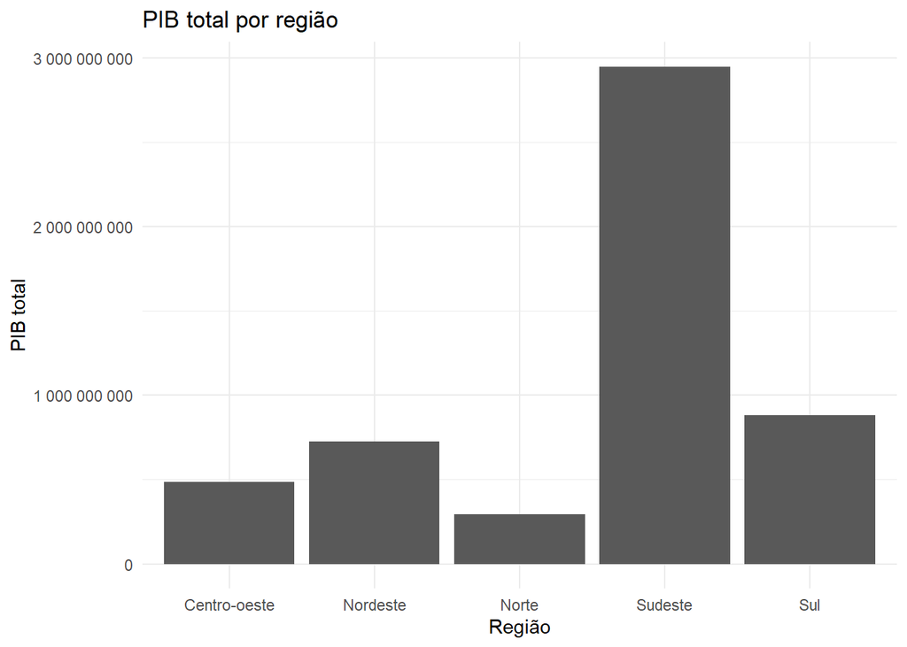

R: Feito!!